# R Notebook

Human Resources Analytics: Kaggle

Why are our best and most experienced employees leaving prematurely? Have fun with this database and try to predict which valuable employees will leave next. Fields in the dataset include:

Employee satisfaction level

Last evaluation

Number of projects

Average monthly hours

Time spent at the company

Whether they have had a work accident

Whether they have had a promotion in the last 5 years

Sales

Salary

Whether the employee has left

```r
library(dplyr)
library(tidyr)
library(ggplot2)
library(ggvis)
library(corrplot)
library(DT)
library(readr)
suppressMessages(alldata <-read_csv("HR_comma_sep.csv"))
```

```r
dim(alldata)
```

```
[1] 14999    10
```

```r
summary(alldata)
```

```
 satisfaction_level last_evaluation  number_project  average_montly_hours time_spend_company Work_accident
 Min.   :0.0900     Min.   :0.3600   Min.   :2.000   Min.   : 96.0        Min.   : 2.000     Min.   :0.0000
 1st Qu.:0.4400     1st Qu.:0.5600   1st Qu.:3.000   1st Qu.:156.0        1st Qu.: 3.000     1st Qu.:0.0000
 Median :0.6400     Median :0.7200   Median :4.000   Median :200.0        Median : 3.000     Median :0.0000
 Mean   :0.6128     Mean   :0.7161   Mean   :3.803   Mean   :201.1        Mean   : 3.498     Mean   :0.1446
 3rd Qu.:0.8200     3rd Qu.:0.8700   3rd Qu.:5.000   3rd Qu.:245.0        3rd Qu.: 4.000     3rd Qu.:0.0000
 Max.   :1.0000     Max.   :1.0000   Max.   :7.000   Max.   :310.0        Max.   :10.000     Max.   :1.0000
      left        promotion_last_5years    sales              salary
 Min.   :0.0000   Min.   :0.00000       Length:14999       Length:14999
 1st Qu.:0.0000   1st Qu.:0.00000       Class :character   Class :character
 Median :0.0000   Median :0.00000       Mode  :character   Mode  :character
 Mean   :0.2381   Mean   :0.02127
 3rd Qu.:0.0000   3rd Qu.:0.00000
 Max.   :1.0000   Max.   :1.00000
```

Let us now look at the correlations between our variables:

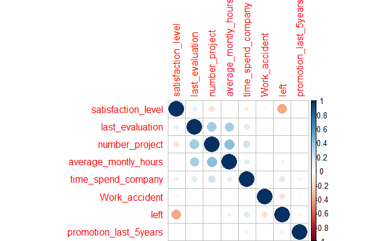

```r
HR_correlation <- alldata %>% select(satisfaction_level:promotion_last_5years)
M <- cor(HR_correlation)
corrplot(M, method="circle")
```

Let’s consider now only those who leave:

```r
leavers <- alldata %>% filter(left==1)
nrow(leavers)
```

```
[1] 3571
```

and let’s see what features they had

```r
par(mfrow=c(1,3))
hist(leavers$satisfaction_level,col="#3090C7", main = "Satisfaction level")
hist(leavers$last_evaluation,col="#3090C7", main = "Last evaluation")
```

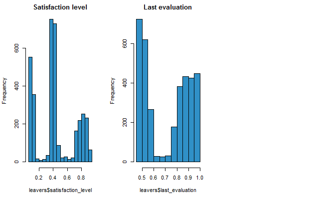

```r
hist(leavers$time_spend_company,col="#3090C7", main = "Time spent in the company")
```

[output not shown]

Looking at the “Last evaluation” graph, we see an interesting distribution. It seems that those who who received a poor evaluation and those who scored highly on the evaluation were likely to leave. Those who were in-between, were likely to stay. However, we need to see whether the dstribution of evaluations was uniform. If there are very few lukewarm evaluations, then we can’t conclude much.

```r
par(mfrow=c(1,3))
hist(alldata$satisfaction_level,col="#3090C7", main = "Satisfaction level")
hist(alldata$last_evaluation,col="#3090C7", main = "Last evaluation")
```

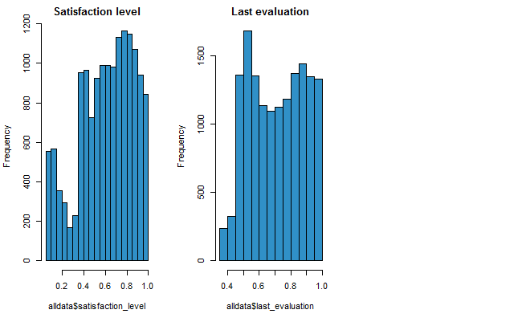

```r
hist(alldata$time_spend_company,col="#3090C7", main = "Time spent in the company")
```

[output not shown]

Now we are much more confident in saying that “mediocre” employees will stay, while bad ones and good ones will leave. Of course we also see that those who leave are statistically less satisfied.

The number of leavers is

```r
nrow(leavers)
```

```
[1] 3571
```

Let’s look at employees that should have been retained. These are the ones that either received a high evaluation or worked on many projects at once.

```r
good_leavers <- leavers %>% filter(last_evaluation >= 0.75 | number_project >= 5)
nrow(good_leavers)
```

```
[1] 1946
```

This turns out to be the majority of employees that left the company. So there is indeed a potential for improvement when it comes to retaining the desirable employees.

Next, we will build a predictive model for which employees will leave next.

I’ll add a 0-1 column that specifies whether a worker is a “good leaver” or not and remove the column for left.

```r
alldata$goodleft <- 1*((alldata$last_evaluation>=0.75 | alldata$number_project>=5) & alldata$left==1)
alldata$left <- NULL
head(alldata)
```

| satisfaction_level | last_evaluation | number_project | average_montly_hours | time_spend_company | Work_accident | promotion_last_5years | sales | salary | goodleft |
| --- | --- | --- | --- | --- | --- | --- | --- | --- | --- |
| 0.38 | 0.53 | 2 | 157 | 3 | 0 | 0 | sales | low | 0 |
| 0.80 | 0.86 | 5 | 262 | 6 | 0 | 0 | sales | medium | 1 |
| 0.11 | 0.88 | 7 | 272 | 4 | 0 | 0 | sales | medium | 1 |
| 0.72 | 0.87 | 5 | 223 | 5 | 0 | 0 | sales | low | 1 |
| 0.37 | 0.52 | 2 | 159 | 3 | 0 | 0 | sales | low | 0 |
| 0.41 | 0.50 | 2 | 153 | 3 | 0 | 0 | sales | low | 0 |

```r
library("caret")
split=0.80
trainIndex <- createDataPartition(alldata$goodleft, p=split, list=FALSE)
train <- alldata[ trainIndex,]
test <- alldata[-trainIndex,]
```

```r
model <- glm (goodleft ~ ., data = train, family = binomial)
summary(model)
```

```
Call:
glm(formula = goodleft ~ ., family = binomial, data = train)

Deviance Residuals:
    Min       1Q   Median       3Q      Max
-2.7796  -0.1981  -0.0607  -0.0100   3.8173

Coefficients:
                        Estimate Std. Error z value Pr(>|z|)
(Intercept)           -25.367477   0.710263 -35.716  < 2e-16 ***
satisfaction_level     -0.172271   0.174122  -0.989    0.322
last_evaluation         9.705475   0.409219  23.717  < 2e-16 ***
number_project          1.268897   0.052929  23.973  < 2e-16 ***
average_montly_hours    0.026141   0.001248  20.939  < 2e-16 ***
time_spend_company      0.533592   0.027228  19.597  < 2e-16 ***
Work_accident          -1.456099   0.165628  -8.791  < 2e-16 ***
promotion_last_5years  -2.951680   0.646643  -4.565 5.00e-06 ***
saleshr                 0.234525   0.265040   0.885    0.376
salesIT                -0.251352   0.235532  -1.067    0.286
salesmanagement        -0.350305   0.302387  -1.158    0.247
salesmarketing         -0.235270   0.262889  -0.895    0.371
salesproduct_mng       -0.296619   0.255441  -1.161    0.246
salesRandD             -0.273514   0.267887  -1.021    0.307
salessales              0.019286   0.198958   0.097    0.923
salessupport            0.233142   0.211403   1.103    0.270
salestechnical          0.181139   0.205804   0.880    0.379
salarylow               2.311894   0.259564   8.907  < 2e-16 ***
salarymedium            1.746429   0.260078   6.715 1.88e-11 ***
---
Signif. codes:  0 â***â 0.001 â**â 0.01 â*â 0.05 â.â 0.1 â â 1

(Dispersion parameter for binomial family taken to be 1)

    Null deviance: 9326.4  on 11999  degrees of freedom
Residual deviance: 3540.9  on 11981  degrees of freedom
AIC: 3578.9

Number of Fisher Scoring iterations: 8
```

```r
predict <- predict(model, type = 'response')
confusion_train=table(train$goodleft, predict > 0.5)
# accuracy on test data
(confusion_train[1,1]+confusion_train[2,2])/nrow(train)
```

```
[1] 0.94825
```

```r
prediction<-(predict.glm(model, test[,-10],type='response')>0.5)*1
# accuracy on test data
sum((prediction==test[,10])*1)/nrow(test)
```

```
[1] 0.954985
```

It looks like logistic regression does a very good job on the data. We can now predict which good workers are likely to leave. It is interesting to look at the coefficients in the regression to get a sense of what factors can predict that a worker is both good and likely to leave:

```r
coefficients(model)
```

```
          (Intercept)    satisfaction_level       last_evaluation        number_project  average_montly_hours
         -25.36747717           -0.17227088            9.70547475            1.26889680            0.02614052
   time_spend_company         Work_accident promotion_last_5years               saleshr               salesIT
           0.53359227           -1.45609896           -2.95167954            0.23452531           -0.25135179
      salesmanagement        salesmarketing      salesproduct_mng            salesRandD            salessales
          -0.35030495           -0.23527032           -0.29661932           -0.27351431            0.01928607
         salessupport        salestechnical             salarylow          salarymedium
           0.23314188            0.18113934            2.31189448            1.74642870
```